# Life Expectancy Over Time by Continent

2024-12-10

## Project Background

Life expectancy reflects the overall quality of life in a country and it is a key indicator of population health and socio-economic development. This analysis examines global trends in life expectancy from 1990 to 2022, focusing on differences across continents.

## Data Origins

The data was obtained from the [World Bank Group](https://databank.worldbank.org/source/world-development-indicators), where I manually selected the variables I was interested in. Under database, I selected life expectancy at birth, females, life expectancy at birth, males, life expectancy at birth, total. Under country, I manually selected all 196 countries, and for time, I selected the years 1990 to 2023. In total, the data has 589 data entries.

## Research Question

**How has life expectancy across different continents change throughout the years?**

It could be interesting to look at changes in average life expectancy as it reflects the health and well-being of populations, as well as a country’s development. Examining how it has changed across continents over time highlights global progress and disparities in healthcare, economic growth, and social policies. Gaining insights into these trends can help to promote health equity and sustainable development by highlighting areas that require attention.

```r
#Loading data into R
data <- read_excel(here("data", "WorldLifeExp.xlsx"))
#Displaying the data
head(data)
```

```
## # A tibble: 6 × 38
##   `Country Name` `Country Code` `Series Name`      `Series Code` `1990 [YR1990]`
##   <chr>          <chr>          <chr>              <chr>         <chr>
## 1 Afghanistan    AFG            Life expectancy a… SP.DYN.LE00.… 48.397
## 2 Afghanistan    AFG            Life expectancy a… SP.DYN.LE00.… 43.709
## 3 Afghanistan    AFG            Life expectancy a… SP.DYN.LE00.… 45.967
## 4 Algeria        DZA            Life expectancy a… SP.DYN.LE00.… 68.517
## 5 Algeria        DZA            Life expectancy a… SP.DYN.LE00.… 66.313
## 6 Algeria        DZA            Life expectancy a… SP.DYN.LE00.… 67.416
## # ℹ 33 more variables: `1991 [YR1991]` <chr>, `1992 [YR1992]` <chr>,
## #   `1993 [YR1993]` <chr>, `1994 [YR1994]` <chr>, `1995 [YR1995]` <chr>,
## #   `1996 [YR1996]` <chr>, `1997 [YR1997]` <chr>, `1998 [YR1998]` <chr>,
## #   `1999 [YR1999]` <chr>, `2000 [YR2000]` <chr>, `2001 [YR2001]` <chr>,
## #   `2002 [YR2002]` <chr>, `2003 [YR2003]` <chr>, `2004 [YR2004]` <chr>,
## #   `2005 [YR2005]` <chr>, `2006 [YR2006]` <chr>, `2007 [YR2007]` <chr>,
## #   `2008 [YR2008]` <chr>, `2009 [YR2009]` <chr>, `2010 [YR2010]` <chr>, …
```

## Data Cleaning and Preparation

```r
#Removing unneccessary columns
data <- data %>%
  select(-`Country Code`, -`Series Code`, -`2023 [YR2023]`)

#Removing rows with no value assigned
data <- data %>%
  filter(!if_any(everything(), ~ . == ".."))

#Renaming columns so it is easier to read
data <- data %>%
  rename(`1990` = `1990 [YR1990]`, `1991` = `1991 [YR1991]`, `1992` = `1992 [YR1992]`, `1993` = `1993 [YR1993]`, `1994` = `1994 [YR1994]`, `1995` = `1995 [YR1995]`, `1996` = `1996 [YR1996]`, `1997` = `1997 [YR1997]`, `1998` = `1998 [YR1998]`, `1999` = `1999 [YR1999]`, `2000` = `2000 [YR2000]`, `2001` = `2001 [YR2001]`, `2002` = `2002 [YR2002]`, `2003` = `2003 [YR2003]`, `2004` = `2004 [YR2004]`, `2005` = `2005 [YR2005]`, `2006` = `2006 [YR2006]`, `2007` = `2007 [YR2007]`, `2008` = `2008 [YR2008]`, `2009` = `2009 [YR2009]`, `2010` = `2010 [YR2010]`, `2011` = `2011 [YR2011]`, `2012` = `2012 [YR2012]`, `2013` = `2013 [YR2013]`, `2014` = `2014 [YR2014]`, `2015` = `2015 [YR2015]`, `2016` = `2016 [YR2016]`, `2017` = `2017 [YR2017]`, `2018` = `2018 [YR2018]`, `2019` = `2019 [YR2019]`, `2020` = `2020 [YR2020]`, `2021` = `2021 [YR2021]`, `2022` = `2022 [YR2022]`)

data <- data %>%
  rename(`Population Group` = `Series Name`)

#Converting relevant columns to numeric
data <- data %>%
  mutate(across(c(`1990`, `1991`, `1992`, `1993`, `1994`, `1995`, `1996`, `1997`,
                  `1998`, `1999`, `2000`, `2001`, `2002`, `2003`, `2004`, `2005`,
                  `2006`, `2007`, `2008`, `2009`, `2010`, `2011`, `2012`, `2013`,
                  `2014`, `2015`, `2016`, `2017`, `2018`, `2019`, `2020`, `2021`, `2022`),
                ~ as.numeric(as.character(.))))

#Rounding up life expectancy values to two decimal points
data <- data %>%
  mutate(across(where(is.numeric), ~ round(., 2)))

#Renaming variables so it is easier to read
data <- data %>%
  mutate(`Population Group` = recode(
    `Population Group`,
    `Life expectancy at birth, total (years)` = "Total",
    `Life expectancy at birth, male (years)` = "Male",
    `Life expectancy at birth, female (years)` = "Female"
  ))
```

As there are so many countries, it would be difficult to visualise the data efficiently. Hence, I used the countrycode package to sort the countries into their specific continents.

```r
#Correcting the way some countries were typed so it matches data in countrycode package
manual_corrections <- data.frame(
  Country = c("Bahamas, The", "Congo, Rep.", "Congo, Dem. Rep.", "Egypt, Arab Rep.", "Gambia, The.", "Hong Kong SAR, China", "Korea, Rep.", "Iran, Islamic Rep.", "Korea, Dem. People's Rep.", "Lao PDR", "Kyrgyz Republic", "Micronesia, Fed. Sts.", "Russian Federation", "Syrian Arab Republic", "Venezuela, RB", "Yemen, Rep.", "Viet Nam"),
  Corrected = c("Bahamas", "Republic of the Congo", "Democratic Republic of the Congo", "Egypt", "Gambia", "Hong Kong", "South Korea", "Iran", "North Korea", "Laos", "Kyrgyzstan", "Micronesia (Federated States of)", "Russia", "Syria", "Venezuela", "Yemen", "Vietnam")
)

data <- data %>%
  left_join(manual_corrections, by = c("Country Name" = "Country")) %>%
  mutate(`Country Name` = if_else(is.na(Corrected), `Country Name`, Corrected)) %>%
  select(-Corrected)

#Using the countrycode package and creating a new column for continent and sorting countries under it
data <- data %>%
  mutate(Continent = countrycode(`Country Name`, origin = "country.name", destination = "continent"))

#Manually assigning Kosovo to Europe as countrycode couldn't identify its continent
data <- data %>%
  mutate(Continent = if_else(`Country Name` == "Kosovo", "Europe", Continent))

#Renaming "Americas" to "North & South America" in the continent column
data <- data %>%
  mutate(Continent = if_else(Continent == "Americas", "North & South America", Continent))

#Moving the continent column next to the country name column for better readability
data <- data %>%
  select(1, Continent, everything())
```

I filtered out the total life expectancy rows so I can compare total life expectancy across continents.

```r
total_data <- data %>%
  filter(`Population Group` == "Total")
```

Next, I converted the data frame into a long format.

```r
#Reshaping my data into long format
long_data <- total_data %>%
  pivot_longer(
    cols = `1990`:`2022`,  #Columns for each year
    names_to = "Year",     #Name for the new column with years
    values_to = "Life Expectancy"  #Name for the new column with values
  ) %>%
  mutate(Year = as.numeric(Year))  #Convert year to numeric
```

Finally, I calculated the average life expectancy for each continent and year.

```r
continent_data <- long_data %>%
  group_by(Continent, Year) %>%
  summarise(Average_Life_Expectancy = mean(`Life Expectancy`, na.rm = TRUE), .groups = "drop")

str(continent_data$Year) #Ensuring year column is properly structured
range(continent_data$Year, na.rm = TRUE) #Check range

continent_data <- continent_data %>% filter(!is.na(Year) & Year != Inf) #Removes rows with invalid or missing year values
```

[output not shown]

## Initial visualisation

This is the first graph that I plotted with the data above.

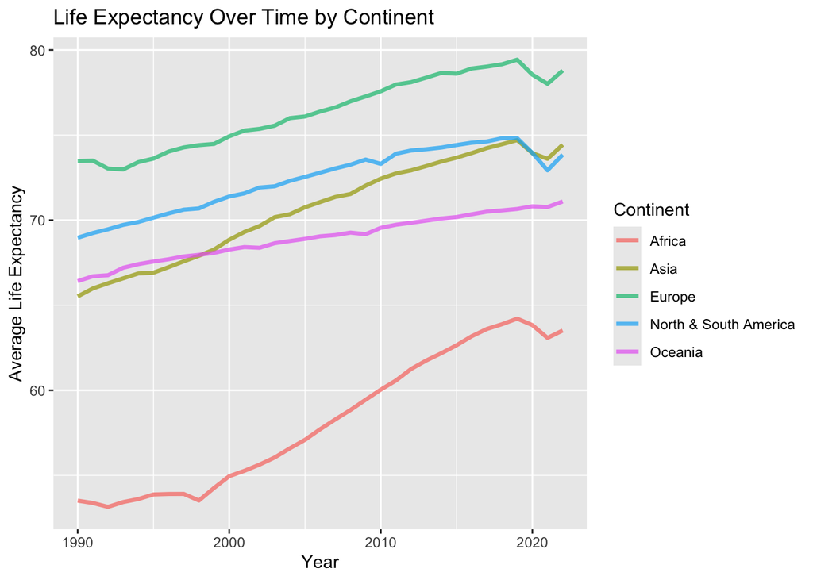

```r
p <- ggplot(continent_data, aes(x = Year, y = Average_Life_Expectancy, color = Continent, group = Continent)) +
  geom_line(linewidth = 1.2, alpha = 0.7) +  #Lines for each continent
  labs(title = "Life Expectancy Over Time by Continent",
    x = "Year",
    y = "Average Life Expectancy")

p
```

```r
#Saving the graph into figs folder
ggsave("figs/initialgraph.png", plot = p, width = 8, height = 6, dpi = 300)
```

But this is a bad graph as the year and average life expectancy values are spread too far apart, making it hard to visualise the average life expectancy per year.

## Improving on Initial Visualisation

Therefore, I improved my code and added these few things:

1. Changed the font size of my graph and centralised the title and subtitle.
2. Changed the colour of the continents according to the Olympics colour coding system.
3. Coded every year to appear on the graph for better visualisation.
4. Adjusted the y-axis range so that average life expectancy values are spaced by intervals of five.
5. Adjusted the x-axis to account for every year between 1990-2022.

```r
#Setting a theme for the graph
graph_theme <- theme(
  plot.title = element_text(hjust = 0.5, size = 14, face = "bold"),  #Main title in bold and centralised
  plot.subtitle = element_text(hjust = 0.5, size = 12, face = "italic"),  #Subtitle in italic and centralised
  axis.text.x = element_text(angle = 45, hjust = 1),  #Rotate x-axis labels
  legend.title = element_text(face = "bold", size = 12),  #Legend title in bold
  legend.text = element_text(size = 12)  #Legend text size
)

#Colour coding each continent according to the Olympics
continent_colours <- c(
  "Europe" = "#0066B3",
  "Asia" = "#FFCC00",
  "Africa" = "#000000",
  "Oceania" = "#009639",
  "North & South America" = "#F44336"
)
```

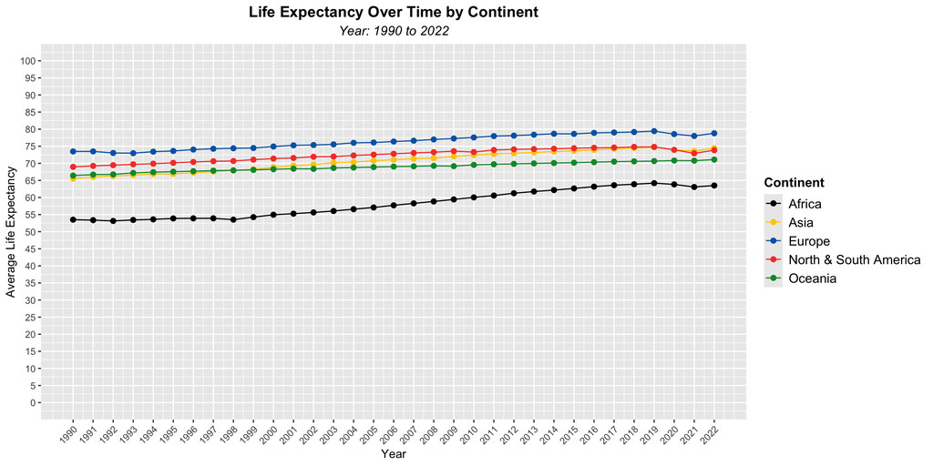

```r
#Plotting a better graph with the changes
p2 <- ggplot(continent_data, aes(x = Year, y = Average_Life_Expectancy, color = Continent, group = Continent)) +
  geom_line() +
  geom_point(size = 2) +  #Points for each year for each continent
  labs(
    title = "Life Expectancy Over Time by Continent",
    subtitle = "Year: 1990 to 2022",
    x = "Year",
    y = "Average Life Expectancy") +
  scale_x_continuous(
    breaks = seq(min(continent_data$Year), max(continent_data$Year), by = 1)) + #Show a label every year
  scale_y_continuous(
    breaks = seq(0, 100, by = 5),  #Adjust y-axis ticks for more specific ranges
    limits = c(0, 100) ) +            #Set the y-axis range
  scale_color_manual(values = continent_colours) +  #Apply Olympic colours
  graph_theme

p2
```

```r
#Saving the plot
ggsave("figs/secondgraph.png", plot = p2, width = 12, height = 6, dpi = 300)
```

## Animating The Plot

To make my graph more interactive and better visualised, I decided to animate it to show how average life expectancy changes across continents across the years.

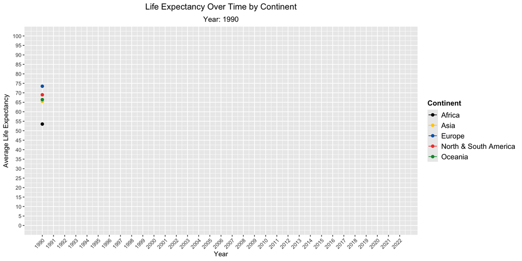

```r
animated_plot <- p2 +
  labs(subtitle = "Year: {round(frame_along, 0)}") + #Round the year to remove decimals
  transition_reveal(Year) #Animates the line to reveal over time

animated_plot
```

## Summary

It can also be seen that Asia and Europe showed more consistent increases, while Africa had more fluctuation. This can be attributed to epidemics, such as HIV/AIDS, that plagued Africa in the 1990s.

## Future Directions

If given more time and data, I would include more factors like GDP per capita or access to healthcare. These factors may help explain why trends in life expectancy differ between continents and may reflect how public health interventions and economic development directly influence life expectancy. It may also aid in predictive modelling.

## References

Boutayeb, A. (2010). The impact of infectious diseases on the development of Africa. Handbook of disease burdens and quality of life measures, 1171.